# COVID-19 and Crime in Atlanta

Wonnetz Phanthavong

10/17/2021

Hello!  
My name is Wonnetz Phanthavong and I’m an aspiring analyst residing in Atlanta, GA.

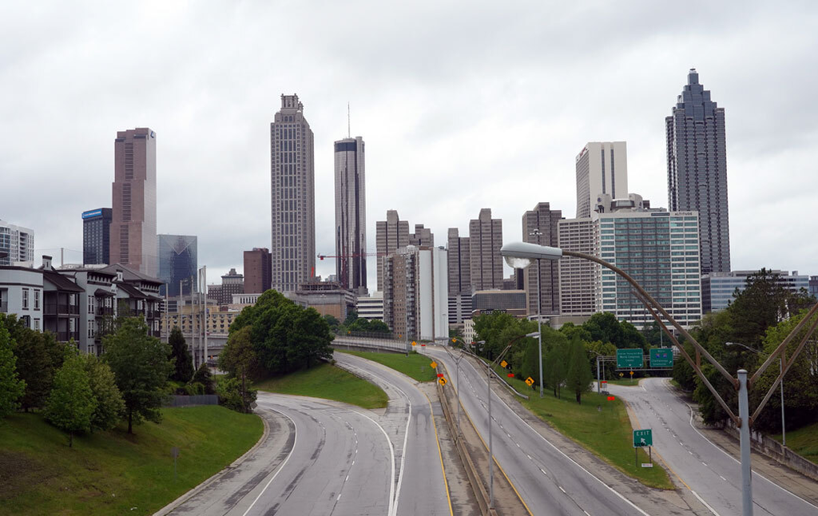

[Back to the Homepage](https://wonnetz.github.io/my-website/)

# 1 Motivation

I recently completed the [Google Data Analytics certificate](https://www.credly.com/badges/beba2698-ca1d-4950-b91a-b0c2acc8a474?source=linked_in_profile) and was looking to put my skills to the test. So why not see how COVID-19 has impacted crime in Atlanta?  
The pandemic has affected a great many lives around the world. Of course, this includes the city that I live in. What I will be exploring here is the impact that COVID-19 has/had on the total crime in Atlanta, GA. What correlations, if any, exist between these data sets? What will I be able to learn from this analysis? What areas could be explored more in the future? Find out at the conclusion of this document!

[Click here if you want to immediately see the results!](https://wonnetz.github.io/my-website/COV19_and_Crime_in_Atlanta.html#conclusion)

# 2 Setting Up my Environment

The data we’re using can be found on the [Atlanta Police Department website](https://www.atlantapd.org/i-want-to/crime-data-downloads) and the [Fulton County Epidemiology Reports](https://www.fultoncountyga.gov/covid-19/epidemiology-reports).

Lets start loading our packages and data sets that we will be using!

```r
library("tidyverse") # Standard Data Analysis Package
library("lubridate") # Standard Date Package
library("readr") # Standard Package to read files
library("prettydoc") # Nice looking themes for the document
library("ggthemes") # Nice looking themes for the plot

# The Data!
COBRA_2009_2019 <- read.csv("COBRA-2009-2019.csv")
COBRA_2020_OLD <- read.csv("COBRA-2020(OLD RMS).csv")
COBRA_2020 <- read.csv("COBRA-2020(NEW RMS).csv")
COBRA_2021 <- read.csv("COBRA-2021.csv")
COV19 <- read.csv("COV19 Cases in Atlanta.csv")
```

# 3 Previewing the Data

To thoroughly conduct our analysis, it would be wise to combine all of our data into a single data frame and for us to clean it from there.

First lets see what we can glimpse from the data. This will be able to tell us how we should proceed.

```r
head(COBRA_2009_2019)
```

|  | Report.Number | Report.Date | Occur.Date | Occur.Time | Possible.Date | Possible.Time | Beat | Apartment.Office.Prefix | Apartment.Number | Location | Shift.Occurence | Location.Type | UCR.Literal | UCR.. | IBR.Code | Neighborhood | NPU | Latitude | Longitude |
| --- | --- | --- | --- | --- | --- | --- | --- | --- | --- | --- | --- | --- | --- | --- | --- | --- | --- | --- | --- |
| 1 | 90010930 | 2009-01-01 | 2009-01-01 | 1145 | 2009-01-01 | 1148 | 411 |  |  | 2841 GREENBRIAR PKWY | Day Watch | 8 | LARCENY-NON VEHICLE | 630 | 2303 | Greenbriar | R | 33.68845 | -84.49328 |
| 2 | 90011083 | 2009-01-01 | 2009-01-01 | 1330 | 2009-01-01 | 1330 | 511 |  |  | 12 BROAD ST SW | Day Watch | 9 | LARCENY-NON VEHICLE | 630 | 2303 | Downtown | M | 33.75320 | -84.39201 |
| 3 | 90011208 | 2009-01-01 | 2009-01-01 | 1500 | 2009-01-01 | 1520 | 407 |  |  | 3500 MARTIN L KING JR DR SW | Unknown | 8 | LARCENY-NON VEHICLE | 630 | 2303 | Adamsville | H | 33.75735 | -84.50282 |
| 4 | 90011218 | 2009-01-01 | 2009-01-01 | 1450 | 2009-01-01 | 1510 | 210 |  |  | 3393 PEACHTREE RD NE | Evening Watch | 8 | LARCENY-NON VEHICLE | 630 | 2303 | Lenox | B | 33.84676 | -84.36212 |
| 5 | 90011289 | 2009-01-01 | 2009-01-01 | 1600 | 2009-01-01 | 1700 | 411 |  |  | 2841 GREENBRIAR PKWY SW | Unknown | 8 | LARCENY-NON VEHICLE | 630 | 2303 | Greenbriar | R | 33.68677 | -84.49773 |
| 6 | 90011327 | 2009-01-01 | 2009-01-01 | 1645 | 2009-01-01 | 1645 | 609 |  |  | 1217 CAROLINE ST NE | Evening Watch | 24 | LARCENY-NON VEHICLE | 630 | 2303 | Edgewood | O | 33.75786 | -84.34875 |

```r
head(COBRA_2020_OLD)
head(COBRA_2020)
head(COBRA_2021)
```

```r
head(COV19)
```

|  | Date | Cumulative.Diagnoses.rate..per.100.000 | Total.Covid.Cases |
| --- | --- | --- | --- |
| 1 | 4/29/2020 | 288.00 | 1,271.00 |
| 2 | 5/27/2020 | 454.00 | 2,007.00 |
| 3 | 6/29/2020 | 690.00 | 3,043.00 |
| 4 | 7/31/2020 | 1,805.00 | 7,964.00 |
| 5 | 8/31/2020 | 2,394.00 | 10,563.00 |
| 6 | 9/29/2020 | 2,662.00 | 11,744.00 |

Note: I decided to only display the 2009-2019 COBRA data set and the COVID-19 data set as to not clutter the document.

It seems that all 4 data frames have a case identification number, date of occurrence, neighborhood, and type of crime. These are the attributes that I’d like to join our tables on! Unfortunately, the data frames vary in both name, data type, and there may also be some overlaps in the data. We’ll have to clean these up before we join the data together.

# 4 Cleaning the Atlanta PD Data

```r
# This renames the case numbers
names(COBRA_2009_2019)[names(COBRA_2009_2019) == "Report.Number"] <- "offense_id"
names(COBRA_2020)[names(COBRA_2020) == "ï..offense_id"] <- "offense_id"

# This renames the column names for date of occurrence and the type of crimes
names(COBRA_2009_2019)[names(COBRA_2009_2019) == "Occur.Date"] <- "occur_date"
names(COBRA_2009_2019)[names(COBRA_2009_2019) == "UCR.Literal"] <- "UC2_Literal"
names(COBRA_2009_2019)[names(COBRA_2009_2019) == "Neighborhood"] <- "neighborhood"

# Converts this column from a double to an integer
COBRA_2009_2019$offense_id <- as.numeric(COBRA_2009_2019$offense_id)

# Converts the strings in the "occur_date" column into Date data types
COBRA_2009_2019 <- COBRA_2009_2019 %>% transform(occur_date = ymd(occur_date))
COBRA_2020_OLD <- COBRA_2020_OLD %>%transform(occur_date = mdy(occur_date))
COBRA_2020 <- COBRA_2020 %>% transform(occur_date = mdy(occur_date))
COBRA_2021 <- COBRA_2021 %>% transform(occur_date = mdy(occur_date))
```

Now that the attributes we want have been standardized, lets filter out the columns that we don’t plan to use.

```r
# Filters the Atlanta PD Data Sets
COBRA_2009_2019 <- COBRA_2009_2019 %>% select(c("offense_id", "occur_date", "UC2_Literal", "neighborhood"))
COBRA_2020_OLD <- COBRA_2020_OLD %>% select(c("offense_id", "occur_date", "UC2_Literal", "neighborhood"))
COBRA_2020 <- COBRA_2020 %>% select(c("offense_id", "occur_date", "UC2_Literal", "neighborhood"))
COBRA_2021 <- COBRA_2021 %>% select(c("offense_id", "occur_date", "UC2_Literal", "neighborhood"))
```

Now we can merge all of the Atlanta PD data into one file!  
Note: As with any process, it’s always a good idea to make sure that duplicates and “NA” values are removed from the data set, which is why we used the distinct() and na.omit() functions.

```r
# Merges the Atlanta PD data sets together
COBRA <- merge(COBRA_2009_2019, COBRA_2020_OLD, all = TRUE) %>%
  merge(COBRA_2020, all = TRUE) %>%
  merge(COBRA_2021, all = TRUE) %>%
  distinct() %>% na.omit()
COBRA <- COBRA %>% filter(occur_date > as.Date("2016-12-31") & occur_date < as.Date("2021-09-1"))
head(COBRA)
```

|  | offense_id | occur_date | UC2_Literal | neighborhood |
| --- | --- | --- | --- | --- |
| 1 | 21140096 | 2021-05-19 | LARCENY-FROM VEHICLE | Hills Park |
| 2 | 21282015 | 2021-08-06 | LARCENY-FROM VEHICLE | Downtown |
| 3 | 21320347 | 2021-01-31 | LARCENY-FROM VEHICLE | Downtown |
| 4 | 21791668 | 2021-06-27 | LARCENY-NON VEHICLE | Vine City |
| 5 | 61583880 | 2021-02-11 | LARCENY-FROM VEHICLE | West End |
| 6 | 102010746 | 2018-07-20 | ROBBERY-COMMERCIAL | Grant Park |

Now that we have cleaned the Atlanta PD data set, lets put it into a format that will make it easier to analyze. We can do this by grouping the COBRA data by year and month to make it easier to view overall trends.

```r
# Formatting the data for analysis and assigning it to a dummy dataframe, called "test".
COBRA <- COBRA %>% mutate(month = strftime(COBRA$occur_date, "%m"))
COBRA <- COBRA %>% mutate(year = strftime(COBRA$occur_date, "%Y"))
test <- COBRA %>% group_by(year, month) %>% count(UC2_Literal)
test <- test %>% group_by(year, month) %>% summarise(sum(n))
test <- test %>% mutate(day = "01")
test <- test %>% unite(Date, year, month, day, sep = "-")
names(test)[names(test) == "sum(n)"] <- "Total Crime"
test <- test %>% transform(Date = as.Date(Date))
```

# 5 Cleaning the COV19 Data

Since I personally scraped this data from the Fulton County Epidemiology Reports, [here](https://www.fultoncountyga.gov/covid-19/epidemiology-reports), this data set will be a lot easier to clean.  
As with the COBRA data set, lets change the column names and format the data types.

```r
# Converts the Date column to the Date data type and standardizes them to the first day of the month
COV19 <- COV19 %>% transform(Date = mdy(Date))
day(COV19$Date) <- 1

# Changes the names of the columns to have them be more readable and converts them to be numerical values
colnames(COV19) <- c("Date", "Cumulative Diagnosis Rate", "Total Cases")
COV19$`Cumulative Diagnosis Rate` <- gsub(",", "", COV19$`Cumulative Diagnosis Rate`) %>% as.numeric()
COV19$`Total Cases` <- gsub(",", "", COV19$`Total Cases`) %>% as.numeric()

# Filters out the month of September 2021 since we don't have full crime data for this month
COV19 <- COV19 %>% filter(Date != as.Date("2021-09-01"))
```

Now we will merge the summarized COBRA data and the cleaned COV19 data into one dataframe.

```r
# Combines the filtered "test" data set and COV19 data set for easier visualization and analysis
df <- merge(test, COV19, all = TRUE)
```

# 6 Creating the Plot

We’ll use ggplot2 to create the plot, because it has a lot of handy built in functions. It allows us to easily create line graphs, alter labels, and to annotate our plot.

```r
# Creation of the initial plot, no annotations.
coeff <- 35
plot <- df %>% ggplot(aes(x = Date)) +
  # Graphs two different lines
  geom_line(aes(y = `Total.Crime`, color = "blue"), size = 2, alpha = .8) +
  geom_line(aes(y = (`Total Cases`/ coeff), color = "red"), size = 2, alpha = .8) +
  ylim(0, 3500) +
  # Labels both the y-axis
  scale_y_continuous(
    name = "Total Crime per month",
    sec.axis = sec_axis(~.*coeff, name = "Total Cases of COV19")
  ) +
  # Customizes the x-axis
  scale_x_date(
    date_breaks = "1 year",
    date_labels = "%Y"
  ) +
  # Standard Labels
  labs(title = "Crime in Atlanta per month vs. Total Cases of COVID-19 from 2017 to 2021",
       subtitle = "(per 100,000 of the population)",
       color = "Legend",
       caption = "Data from Atlanta PD and Fulton County Epidemiology Reports"
  )  +
  # Establishes the Legend
  scale_color_manual(labels = c("Total Crime per month", "Total Cases of COV19"), values = c("#006391", "#bc5090")) +
  # Custom Theme
  theme_fivethirtyeight() +
  theme(
        axis.text.x = element_text(angle = 45, hjust = 1, family = "sans", size = 10),
        axis.title.x = element_blank(),
        axis.title = element_text(family = "sans", face = "bold", size = 14),
        legend.key.size = unit(1.5, "cm"),
        legend.text = element_text(size = 10),
        plot.title = element_text(size = 20)
        )
```

Lets add some more information and color to our plot!

```r
# Addded the arrows, lines, extra points, and other annotations to the plot
plot <- plot +
  # Horizontal Line to show Peak Crime and Peak Low
  geom_hline(yintercept = 2463, linetype = 2, size =  1.2, colour = "#ffa600") +
  geom_hline(yintercept = 1081, linetype = 2, size = 1.2, colour = "#ffa600") +
  # Adds a Curved Arrow
  # geom_curve(
  # No trough version
  # x = as.numeric(as.Date("2018-04-01")), y = 1050, xend = as.numeric(as.Date("2020-03-01")), yend = 35,
  # Trough version
  #  x = as.numeric(as.Date("2018-04-01")), y = 550, xend = as.numeric(as.Date("2020-03-01")), yend = 35,
  #  arrow = arrow(
  #  length = unit(0.03, "npc"),
  #              type="closed" # Describes arrow head (open or closed)
  #  ),
  #  colour = "#ffa600",
  #  size = 1.2,
  #  angle = 0) +
  # Annotation
  # geom_text(aes(family = "sans"),
  #          # No Trough Version
  #          # x = as.numeric(as.Date("2018-04-01")), y = 1200,
  #          x = as.numeric(as.Date("2018-04-01")), y = 700,
  #          label = "World Health Organization (WHO) \n declares COVID-19 as a global pandemic.",
  #          colour = "#ffa600", size = 6) +
  # WHO Point
  # geom_point(x = as.Date("2020-04-01"), y = 40,
  #           colour = "#ffa600", size = 6) +

  # Peak Crime Text
  geom_text(aes(family = "sans"),
            x = as.numeric(as.Date("2019-03-01")), y = 2650,
            label = "Record Highs",
            colour = "#ffa600", size = 6) +
  # Peak Crime Point
  geom_point(x = as.Date("2017-10-01"), y = 2485,
             colour = "#ffa600", size = 6) +
  # Peak Crime Point
  geom_point(x = as.Date("2020-11-20"), y = 2463,
             colour = "#ffa600", size = 6) +
  # Trough Crime Text
  geom_text(aes(family = "sans"),
            x = as.numeric(as.Date("2019-03-01")), y = 1200,
            label = "Record Lows",
            colour = "#ffa600", size = 6) +
  # Trough Crime Point
  geom_point(x = as.Date("2020-04-01"), y = 1081,
             colour = "#ffa600", size = 6) +
  theme(text = element_text(family = "sans"))
```

Lets look at our plot, the final product!

# 7 Conclusion

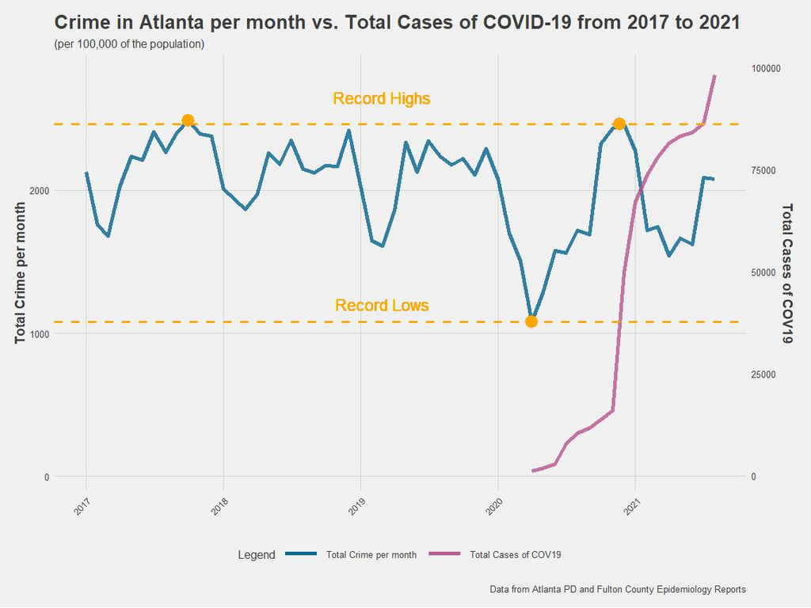

Looking at only the Total Crime in Atlanta per month, we see that over the past 4 years it has fluctuated quite consistently. There is a steady drop off in crime at the start of the year, followed by a rebound in crime after March and April.

The months surrounding COVID-19 have drastically altered the Crime in Atlanta. I found that there was a 41% decrease in crime in April 2019 compared to April 2020 and that there was a marginal increase of 8% in crime in December 2019 compared to December 2020.

# 8 Further Areas to Explore

There are still plenty of questions to explore with this data set and viz. What particular crime increased or decreased around the pandemic? In what neighborhoods of Atlanta did we find this increase/decrease? What other factors/variables could we consider in the future?

These are areas that I may come back to in the future, but for now I feel that I want to dabble into other areas. If you’ve made it this far, thank you for reading! If you have any questions or comments, then feel free to reach out to me.

[Back to the Homepage](https://wonnetz.github.io/my-website/)